# Airline satisfaction data

### Zadovoljstvo prema kombinaciji starosne grupe i klase leta

U prethodnoj analizi uočeno je da se procenat nezadovoljnih putnika razlikuje između starosnih grupa, dok se zadovoljstvo značajno razlikuje i između klasa leta. Zbog toga je potrebno ispitati da li se obrazac starosti održava unutar različitih klasa.

Ovom analizom proverićemo da li starosna grupa ima sličnu povezanost sa zadovoljstvom u svim klasama leta ili se uočene razlike mogu objasniti razlikama u klasi putovanja.

```r
age_class_satisfaction <- data %>%
  count(Age_Group, Class, Satisfaction, name = "Broj") %>%
  group_by(Age_Group, Class) %>%
  mutate(Procenat = round(Broj / sum(Broj) * 100, 2)) %>%
  ungroup()

age_class_satisfaction
```

```
## # A tibble: 30 × 5
##    Age_Group Class    Satisfaction   Broj Procenat
##    <ord>     <fct>    <fct>         <int>    <dbl>
##  1 Under 18  Business Satisfied       662     40.3
##  2 Under 18  Business Not Satisfied   980     59.7
##  3 Under 18  Eco      Satisfied       854     11.9
##  4 Under 18  Eco      Not Satisfied  6297     88.1
##  5 Under 18  Eco Plus Satisfied       131     12.4
##  6 Under 18  Eco Plus Not Satisfied   923     87.6
##  7 18-34     Business Satisfied     10121     60.6
##  8 18-34     Business Not Satisfied  6567     39.4
##  9 18-34     Eco      Satisfied      3449     17.4
## 10 18-34     Eco      Not Satisfied 16365     82.6
## # ℹ 20 more rows
```

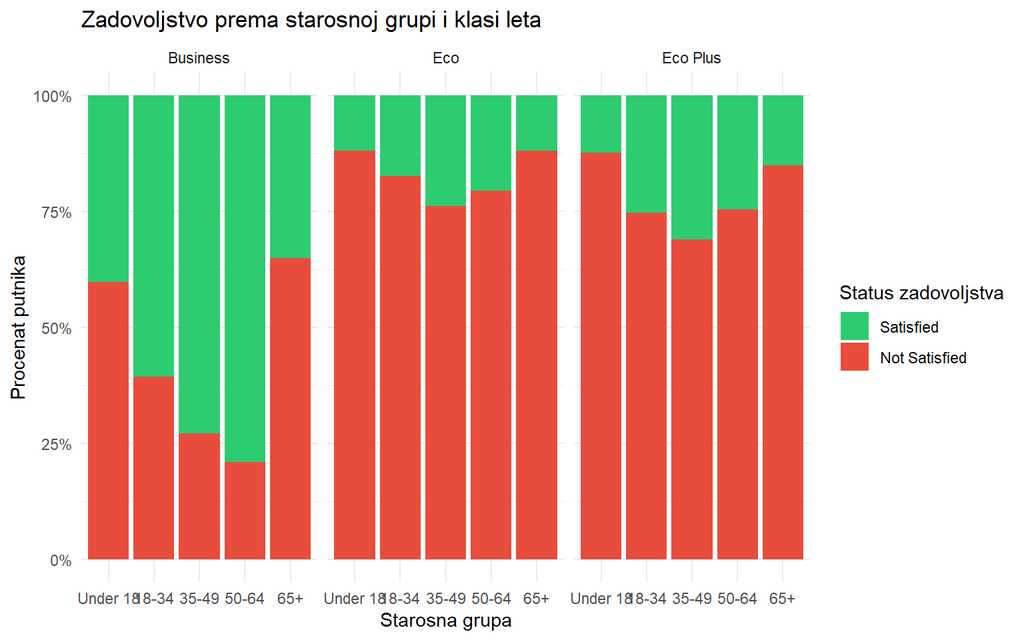

```r
ggplot(
  age_class_satisfaction,
  aes(
    x = Age_Group,
    y = Procenat,
    fill = Satisfaction
  )
) +
  geom_col(position = "fill") +
  facet_wrap(~ Class) +
  scale_y_continuous(labels = scales::percent_format()) +
  scale_fill_manual(
    values = c(
      "Satisfied" = "#2ecc71",
      "Not Satisfied" = "#e74c3c"
    )
  ) +
  theme_minimal() +
  labs(
    title = "Zadovoljstvo prema starosnoj grupi i klasi leta",
    x = "Starosna grupa",
    y = "Procenat putnika",
    fill = "Status zadovoljstva"
  )
```

```r
age_class_table <- table(
  data$Age_Group,
  data$Class,
  data$Satisfaction
)

age_class_chisq <- chisq.test(
  ftable(age_class_table),
  correct = FALSE
)

age_class_chisq
```

```
##
##  Pearson's Chi-squared test
##
## data:  ftable(age_class_table)
## X-squared = 36035, df = 14, p-value < 2.2e-16
```

Rezultati pokazuju da se zadovoljstvo putnika razlikuje prema kombinaciji starosne grupe i klase leta. U svim starosnim grupama poslovna klasa ima veći procenat zadovoljnih putnika u odnosu na Eco i Eco Plus klase.

Ovi rezultati ukazuju da se obrazac povezanosti starosti i zadovoljstva ne može posmatrati nezavisno od klase leta. Klasa leta je povezana sa nivoom zadovoljstva unutar svih starosnih grupa, dok se razlike između starosnih grupa menjaju u zavisnosti od klase.

Pearsonov hi-kvadrat test pokazuje statistički značajnu povezanost između kombinacije starosne grupe i klase leta i zadovoljstva putnika, χ²(14) = 36035, p < 0,001. Zbog toga odbacujemo nultu hipotezu o nezavisnosti.

Ipak, test ne dokazuje uzročno-posledičnu vezu niti samostalno potvrđuje formalnu interakciju između starosne grupe i klase. On pokazuje da se raspodela zadovoljstva značajno razlikuje između posmatranih kombinacija kategorija.

### Zadovoljstvo prema kombinaciji dužine leta i klase

U prethodnoj analizi uočeno je da se zadovoljstvo razlikuje između kategorija dužine leta, pri čemu su putnici na dugim letovima u proseku zadovoljniji. Takođe je utvrđeno da se zadovoljstvo značajno razlikuje između klasa leta.

Zbog toga ćemo proveriti da li se razlike u zadovoljstvu između kratkih, srednjih i dugih letova održavaju unutar svake klase. Na taj način možemo ispitati da li je uočeno veće zadovoljstvo na dugim letovima povezano sa samom dužinom leta ili je delimično posledica različite zastupljenosti klasa leta.

```r
distance_class_satisfaction <- data %>%
  count(Flight_Distance_Category, Class, Satisfaction, name = "Broj") %>%
  group_by(Flight_Distance_Category, Class) %>%
  mutate(Procenat = round(Broj / sum(Broj) * 100, 2)) %>%
  ungroup()

distance_class_satisfaction
```

```
## # A tibble: 18 × 5
##    Flight_Distance_Category Class    Satisfaction   Broj Procenat
##    <ord>                    <fct>    <fct>         <int>    <dbl>
##  1 Short                    Business Satisfied      7501     59.2
##  2 Short                    Business Not Satisfied  5161     40.8
##  3 Short                    Eco      Satisfied      4939     20.9
##  4 Short                    Eco      Not Satisfied 18708     79.1
##  5 Short                    Eco Plus Satisfied      1077     27.2
##  6 Short                    Eco Plus Not Satisfied  2890     72.8
##  7 Medium                   Business Satisfied     10661     64.3
##  8 Medium                   Business Not Satisfied  5929     35.7
##  9 Medium                   Eco      Satisfied      5198     17.8
## 10 Medium                   Eco      Not Satisfied 24008     82.2
## 11 Medium                   Eco Plus Satisfied      1063     23.9
## 12 Medium                   Eco Plus Not Satisfied  3393     76.1
## 13 Long                     Business Satisfied     25004     76.0
## 14 Long                     Business Not Satisfied  7904     24.0
## 15 Long                     Eco      Satisfied       806     14.8
## 16 Long                     Eco      Not Satisfied  4650     85.2
## 17 Long                     Eco Plus Satisfied       179     18.1
## 18 Long                     Eco Plus Not Satisfied   809     81.9
```

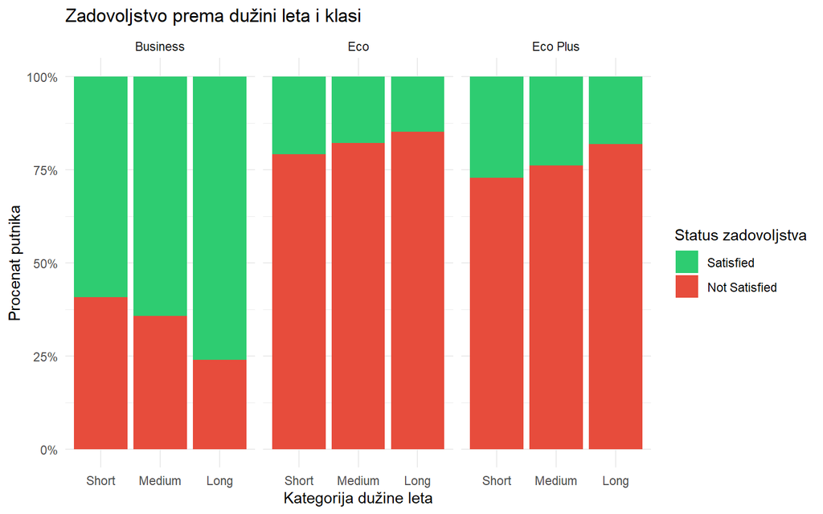

```r
ggplot(
  distance_class_satisfaction,
  aes(
    x = Flight_Distance_Category,
    y = Procenat,
    fill = Satisfaction
  )
) +
  geom_col(position = "fill") +
  facet_wrap(~ Class) +
  scale_y_continuous(labels = scales::percent_format()) +
  scale_fill_manual(
    values = c(
      "Satisfied" = "#2ecc71",
      "Not Satisfied" = "#e74c3c"
    )
  ) +
  theme_minimal() +
  labs(
    title = "Zadovoljstvo prema dužini leta i klasi",
    x = "Kategorija dužine leta",
    y = "Procenat putnika",
    fill = "Status zadovoljstva"
  )
```

```r
distance_class_table <- table(
  data$Flight_Distance_Category,
  data$Class,
  data$Satisfaction
)

distance_class_chisq <- chisq.test(
  ftable(distance_class_table),
  correct = FALSE
)

distance_class_chisq
```

```
##
##  Pearson's Chi-squared test
##
## data:  ftable(distance_class_table)
## X-squared = 34315, df = 8, p-value < 2.2e-16
```

Rezultati pokazuju da se odnos između dužine leta i zadovoljstva razlikuje u zavisnosti od klase leta. U poslovnoj klasi procenat zadovoljnih putnika raste sa dužinom leta: 59,2% kod kratkih, 64,3% kod srednjih i 76,0% kod dugih letova.

Kod ekonomske klase uočava se suprotan obrazac. Procenat zadovoljnih iznosi 20,9% kod kratkih, 17,8% kod srednjih i 14,8% kod dugih letova. Sličan obrazac postoji i u klasi Eco Plus, gde procenat zadovoljnih opada sa 27,2% kod kratkih na 18,1% kod dugih letova.

Ovi rezultati pokazuju da se veće zadovoljstvo kod dugih letova, uočeno u bivarijantnoj analizi, ne održava jednako u svim klasama. Ono je naročito izraženo u poslovnoj klasi, dok se u ekonomskim klasama procenat zadovoljnih putnika smanjuje sa dužinom leta. Zbog toga ukupna povezanost dužine leta sa zadovoljstvom može biti delimično posledica različite strukture putnika po klasama leta.

Pearsonov hi-kvadrat test pokazuje statistički značajnu povezanost između kombinacije kategorije dužine leta i klase i zadovoljstva putnika, χ²(8) = 34315, p < 0,001. Zbog toga odbacujemo nultu hipotezu o nezavisnosti.

Dobijeni rezultat ne dokazuje uzročno-posledičnu vezu niti samostalno potvrđuje formalnu interakciju između dužine leta i klase. Takođe treba imati u vidu da je klasa Eco Plus manje zastupljena, pa rezultate za ovu grupu treba tumačiti opreznije.

## Zaključak analize kategorijskih kombinacija

U ovoj analizi ispitano je da li se zadovoljstvo putnika razlikuje prema kombinacijama važnih kategorijskih promenljivih. Posmatrane su kombinacije klase i svrhe putovanja, tipa korisnika i svrhe putovanja, starosne grupe i klase, kao i kategorije dužine leta i klase.

Rezultati pokazuju da se zadovoljstvo ne može potpuno objasniti posmatranjem samo jedne promenljive. Klasa leta i svrha putovanja imaju posebno izražen značaj, ali se njihov odnos sa zadovoljstvom menja u zavisnosti od druge karakteristike putnika ili leta.

Kod poslovnih putovanja poslovna klasa ima najveći procenat zadovoljnih putnika, dok su kod ličnih putovanja procenti zadovoljnih niski u svim klasama. Lojalni korisnici su znatno zadovoljniji od dislojalnih kod poslovnih putovanja, dok je kod ličnih putovanja zadovoljstvo nisko kod obe grupe. Analiza starosnih grupa pokazuje da razlike između starosti nisu iste u svim klasama leta. Takođe, veće zadovoljstvo kod dugih letova uglavnom se održava u poslovnoj klasi, ali ne i u ekonomskim klasama.

Svi primenjeni hi-kvadrat testovi pokazali su statistički značajne povezanosti, uz nivo značajnosti p < 0,001. Međutim, zbog velikog broja opservacija statistička značajnost ne znači nužno veliku praktičnu važnost. Rezultati ukazuju na povezanost između posmatranih kombinacija kategorija i zadovoljstva, ali ne dokazuju uzročno-posledične veze.

Ovi nalazi predstavljaju osnovu za izbor promenljivih u daljoj multivarijantnoj analizi i izgradnji modela predikcije.